```python
import pandas as pd
import numpy as np
%matplotlib inline
import matplotlib.pyplot as plt
import pandas as pd
import seaborn as sns
```

# Preprocessing

```python
file = 'C:\\Users\\kjumi\\Downloads\\new-york-city-airbnb-open-data\\AB_DATA.csv'
data = pd.io.parsers.read_csv(file)
data = pd.DataFrame(data)
```

```python
print(len(data.columns))
print(len(data))
print(data.columns)
print(set(data['city']))
```

```
29
74111
Index(['id', 'log_price', 'property_type', 'room_type', 'amenities',
       'accommodates', 'bathrooms', 'bed_type', 'cancellation_policy',
       'cleaning_fee', 'city', 'description', 'first_review',
       'host_has_profile_pic', 'host_identity_verified', 'host_response_rate',
       'host_since', 'instant_bookable', 'last_review', 'latitude',
       'longitude', 'name', 'neighbourhood', 'number_of_reviews',
       'review_scores_rating', 'thumbnail_url', 'zipcode', 'bedrooms', 'beds'],
      dtype='object')
{'NYC', 'Chicago', 'LA', 'Boston', 'SF', 'DC'}
```

### Step1: Clean and filter the data

```python
data = data.dropna()
data1 = data[data['log_price'] != 0]
data1 = data[data['city'] == "NYC"]
data1 = data1.reset_index(drop=True)
print(len(data1))
```

```
17856
```

### Step2: Feature Creation

- Add columns with distances between each airbnb and three NYC landmarks (Central Park, Financial District, and SOHO)
- Calculate price from log(price)
- Calculated the spread (date uploaded - last review date)

We expected that there will be a correlation between Airbnb price and distances between landmarks in NYC such as Central Park, Financial District, and SOHO. We calculated the distance with latitude and longitude of each Airbnb.

```python
## find the distance between a airbnb house and landmark
import math

def distance(origin, destination):
    lat1, lon1 = origin
    lat2, lon2 = destination
    radius = 6371 # km

    dlat = math.radians(lat2-lat1)
    dlon = math.radians(lon2-lon1)
    a = math.sin(dlat/2) * math.sin(dlat/2) + math.cos(math.radians(lat1)) * math.cos(math.radians(lat2)) * math.sin(dlon/2) * math.sin(dlon/2)
    c = 2 * math.atan2(math.sqrt(a), math.sqrt(1-a))
    d = radius * c

    return d
```

```python
park_dur = []
fin_dur = []
soho_dur = []

for i in range(len(data1)):
    lat = data1['latitude'][i]
    long = data1['longitude'][i]
    origin = (lat, long)

    # Central park
    central_park = (40.7829,-73.9654)
    # Wall street
    financial = (40.703830518,-74.005666644)
    # Shopping district
    soho = (40.7233,-74.0030)

    #pass origin and destination variables to distance_matrix function# output in meters
    result1 = distance(origin, central_park)
    result2 = distance(origin, financial)
    result3 = distance(origin, soho)

    #append result to list
    park_dur.append(result1)
    fin_dur.append(result2)
    soho_dur.append(result3)
```

```python
data1['Central Park'] = park_dur
data1['Financial District'] = fin_dur
data1['Soho'] = soho_dur
```

The data contains log(price), but we wanted to use the real price in our analysis to intuitively see whether the prices are cheap/ fine / expensive.

```python
p = []
for i in data1['log_price']:
    i = math.exp(i)
    if i-int(i) >= 0.5:
        num = math.ceil(i)
    else:
        num = int(i)
    p.append(num)
```

```python
data1['price'] = p
```

```python
data1.columns
```

```
Index(['id', 'log_price', 'property_type', 'room_type', 'amenities',
       'accommodates', 'bathrooms', 'bed_type', 'cancellation_policy',
       'cleaning_fee', 'city', 'description', 'first_review',
       'host_has_profile_pic', 'host_identity_verified', 'host_response_rate',
       'host_since', 'instant_bookable', 'last_review', 'latitude',
       'longitude', 'name', 'neighbourhood', 'number_of_reviews',
       'review_scores_rating', 'thumbnail_url', 'zipcode', 'bedrooms', 'beds',
       'Central Park', 'Financial District', 'Soho', 'price'],
      dtype='object')
```

For regression analysis, we expect that there will be a correlation between price and "last_review." To change the data in date form into numbers, we calculated the spread between the last review date and date upload date. Then we added to the data.

```python
#changing the review date as the spread between the last date of the data and the date.

import datetime

lastday = datetime.datetime.strptime('2017-10-04', '%Y-%m-%d').date()
spread_list = []
for i in data1['last_review']:
    date = datetime.datetime.strptime(i, '%Y-%m-%d').date()
    spread = lastday - date
    spread = spread.days
    spread_list.append(spread)
```

```python
data1['last_review_diff'] = spread_list
```

Drop irrelevant columns

```python
data2 = data1.drop(['first_review', 'log_price', 'thumbnail_url', 'zipcode'], axis = 1)
```

## 2. Remove outliers

We found that some data points have very little value such that price = 0, 1, 2... We also found a huge number, such as price = 2000, 1999, 1998... We expected that these outliers would affect our prediction of the prices of Airbnb; thus, we decided to remove the outliers.

```python
# too many data with price = 1, which doesn't make sense intuitively, thus we dropped those data.
data3 = data2[data2['price'] != 1]
```

```python
import seaborn as sns
```

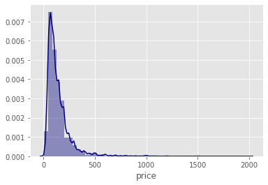

```python
sns.distplot(data3['price'], color = 'Navy')
```

```python
from scipy.stats import zscore
```

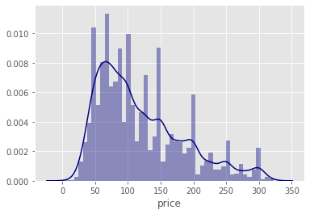

```python
data3['price_zscore'] = zscore(data3['price'])
data3['is_outlier']  =  data3['price_zscore'].apply(lambda x: x <= -1.5 or x >= 1.5)
data4 = data3[data3['is_outlier'] == False]
sns.distplot(data4['price'], color = 'Navy')
```

### The data now contains 32 columns and 16832 rows

#### Attributes including text (name and description)

```python
len(data4)
```

```
16832
```

```python
from wordcloud import WordCloud
```

```python
name = data4['name']
description = data4['description']
name_list = [x for x in name]
description_list = [x for x in description]
```

Words in the name of the airbnb list

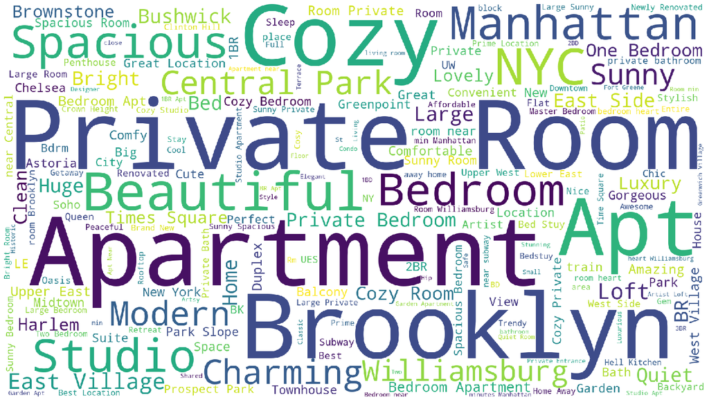

```python
plt.subplots(figsize=(25,15))
wordcloud = WordCloud(
                          background_color='white',
                          width=1920,
                          height=1080
                         ).generate(" ".join(name_list))
plt.imshow(wordcloud)
plt.axis('off')
plt.savefig('neighbourhood.png')
plt.show()
```

words in the description of the airbnb list

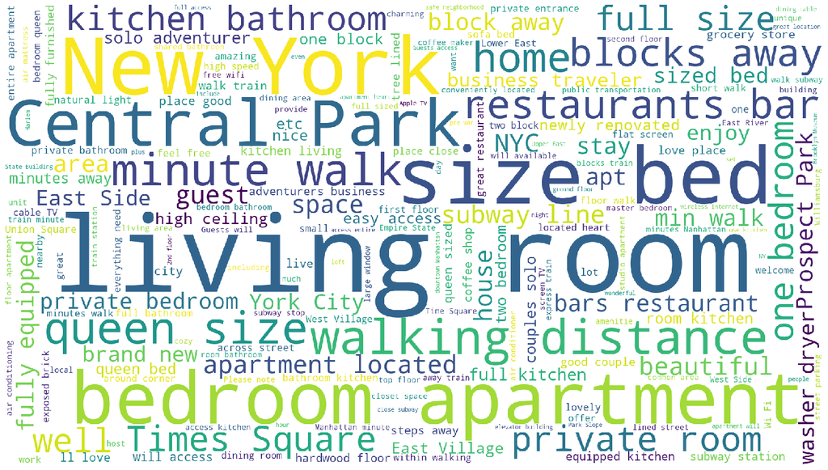

```python
plt.subplots(figsize=(25,15))
wordcloud = WordCloud(
                          background_color='white',
                          width=1920,
                          height=1080
                         ).generate(" ".join(description_list))
plt.imshow(wordcloud)
plt.axis('off')
plt.savefig('neighbourhood.png')
plt.show()
```

### Labeling prices for classification analysis

```python
label = []
for i in data4['price']:
    if i <100:
        label.append(1)
    if i >= 100 & i <200:
        label.append(2)
    if i >= 200 & i < 300:
        label.append(3)
    if i >= 300:
        label.append(4)
```

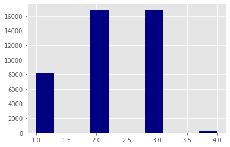

```python
plt.hist(label, color = 'Navy')
```